# Data Science Sampler: Beyond Static Plots

- Show All Code
- Hide All Code
- View Source

Author

Casey Schine

## Overview

In this class, we’ve focused on building solid data analysis skills.

Today, we’re going to look at some *optional tools* that go beyond that—things that make your work:

- interactive
- public-facing
- more engaging

You will **vote on which of these we explore further**.

## Setup

Here is where you may need to install some new packages:

```r
# Uncomment if needed
# install.packages(c("tidyverse", "leaflet", "plotly", "gganimate",
#                    "gapminder", "palmerpenguins"))

library(tidyverse)
library(leaflet) #new
library(plotly) #new
library(gganimate) #new
library(gapminder)
library(palmerpenguins)
```

## Leaflet Interactive Maps

```r
data(quakes)

quakes |>
  slice_sample(n = 300) |>
  leaflet() |>
  addProviderTiles("Esri.OceanBasemap") |>
  addCircleMarkers(
    lng = ~long,
    lat = ~lat,
    # set circle marker to size by magnitude
    radius = ~mag^2/3,
    # make popup labels
    popup = ~paste0(
      "<strong>Magnitude:</strong> ", mag,
      "<br><strong>Depth:</strong> ", depth, " km"
    ),
    stroke = FALSE,
    fillOpacity = 0.6
  )
```

[interactive chart not shown]

Color the points by magnitude and add a legend:

```r
pal <- colorNumeric(
  palette = "viridis",
  domain = quakes$mag
)

leaflet(quakes) |>
  addProviderTiles("Esri.OceanBasemap") |>
  addCircleMarkers(
    lng = ~long,
    lat = ~lat,
    radius = ~mag^2/3,
    color = ~pal(mag),
    stroke = FALSE,
    fillOpacity = 0.7
  ) |>
  addLegend(
    "bottomright",
    pal = pal,
    values = ~mag,
    title = "Magnitude"
  )
```

[interactive chart not shown]

Now let’s start playing around with the basemaps. You can find all of the possibilities on this website:

https://leaflet-extras.github.io/leaflet-providers/preview/

```r
library(leaflet)
library(dplyr)

data(quakes)

small <- quakes |> filter(mag < 5)
large <- quakes |> filter(mag >= 5)

leaflet() |>
  # Basemaps
  addProviderTiles("Esri.WorldImagery", group = "Satellite") |>
  addProviderTiles("Esri.OceanBasemap", group = "Ocean") |>
  addProviderTiles("Stadia.StamenWatercolor", group = "Artsy") |>

  # Small earthquakes
  addCircleMarkers(
    data = small,
    lng = ~long, lat = ~lat,
    radius = 3,
    color = "blue",
    group = "Smaller quakes",
    stroke = FALSE,
    fillOpacity = 0.5
  ) |>

  # Large earthquakes
  addCircleMarkers(
    data = large,
    lng = ~long, lat = ~lat,
    radius = ~mag * 2,
    color = "red",
    group = "Larger quakes",
    stroke = TRUE,
    weight = 1
  ) |>

  # Layer control
  addLayersControl(
    baseGroups = c("Satellite", "Ocean", "Artsy"),
    overlayGroups = c("Smaller quakes", "Larger quakes"),
    options = layersControlOptions(collapsed = FALSE)
  )
```

[interactive chart not shown]

Now with the EJI data. I strongly recommend that you don’t try to run this one.

```r
library(sf)
eji_data <- st_read("~/Dropbox/!Middlebury/Teaching/STAT 118/S2026/S2026_R_Proj/midterm/eji_sf.gpkg")
eji_cali <- eji_data |>
  filter(STATE_NAME=="California") |>
  filter(!is.na(E_LIMENG), E_LIMENG <100)

pal <- colorNumeric(
  palette = "viridis",
  domain = eji_cali$E_LIMENG,
  na.color = "transparent"
)


eji_cali |>
leaflet() |>
  addTiles() |>
  addPolygons(
    fillColor = ~pal(E_LIMENG),
    fillOpacity = 0.7,
    color = "white",
    weight = 0.5,
    popup = ~paste0(
      "<strong>County:</strong> ", COUNTY,
      "<br><strong>Tract:</strong> ", GEOID,
      "<br><strong>Poverty %:</strong> ", E_LIMENG
    )
  ) |>
  addLegend(
    "bottomright",
    pal = pal,
    values = ~E_LIMENG,
    title = "Unemployed",
    opacity = 0.7
  )
```

[interactive chart not shown]

## Plotly Interactive Plots

Plotly doesn’t change your analysis at all — it just changes how your results exist. It turns a static figure into something you could actually put on a website or share with someone to explore.

Let’s start simple. You make a plot in ggplot and then you feed it into plotly and it’s like magic.

```r
p <- ggplot(mpg, aes(x = displ, y = hwy, color = class,
                     text = paste("Model:", model))) +
  geom_point(size = 2, alpha = 0.7) +
  theme_minimal()

ggplotly(p, tooltip = "text")
```

[interactive chart not shown]

Let’s add more information to the pop-up:

```r
p <- ggplot(mpg, aes(x = displ, y = hwy, color = class)) +
  geom_point(
    aes(text = paste(
      "Model:", model,
      "<br>Class:", class,
      "<br>Displacement:", displ,
      "<br>Highway MPG:", hwy
    )),
    size = 2,
    alpha = 0.7
  ) +
  theme_minimal()

ggplotly(p, tooltip = "text")
```

[interactive chart not shown]

Let’s try it with the gapminder data.

```r
p <-  gapminder |>
  filter(year == 2007) |>
  ggplot(aes(x = gdpPercap, y = lifeExp, color = continent)) +
  geom_point(alpha = 0.7) +
  labs(color="Continent") +
  scale_x_log10() +
  scale_size(range = c(2, 10)) +
  ggtitle("Year: 2007") +
  theme_minimal()

ggplotly(p)
```

[interactive chart not shown]

With facets:

```r
p <- ggplot(mpg, aes(displ, hwy, color = class)) +
  geom_point(alpha = 0.7) +
  facet_wrap(~drv) +
  theme_minimal()

ggplotly(p)
```

[interactive chart not shown]

With a boxplot:

```r
p <- ggplot(mpg, aes(class, hwy, fill = class)) +
  geom_boxplot() +
  theme_minimal()

ggplotly(p)
```

[interactive chart not shown]

This is my first time doing this with a boxplot, and now this is the only way I’m making a boxplot ever again!

Let’s do it with a line!

```r
economics <- ggplot2::economics

p <- ggplot(economics, aes(date, unemploy)) +
  geom_line(color = "steelblue") +
  theme_minimal()

ggplotly(p)
```

[interactive chart not shown]

WITH A DENSITY PLOT!

```r
p <- ggplot(diamonds, aes(x = price, fill = cut)) +
  geom_density(alpha = 0.5) +
  theme_minimal()

ggplotly(p)
```

[interactive chart not shown]

This is AMAZING! Why am I only just learning this????

## Animation

```r
p <- ggplot(
  gapminder,
  aes(
    x = gdpPercap,
    y = lifeExp,
    group = country,
    color = continent,
    size = pop
  )
) +
  geom_point(alpha = 0.7) +
  scale_x_log10() +
  scale_color_brewer(palette = "Set1") +
  scale_size_continuous(range = c(1, 10)) +
  theme_minimal() +
  labs(
    title = "Year: {frame_time}",
    x = "GDP per capita",
    y = "Life expectancy",
    color = "Continent",
    size = "Population"
  ) +
  transition_time(year)

animate(
  p,
  nframes = 60,
  fps = 4,
  width = 600,
  height = 400,
  renderer = gifski_renderer(),
  device = "ragg_png"
)
```

[output not shown]

You may be able to tell by how many plots I made with the others and how few animations I have given you, that my heart isn’t really in animations. This single animation took about 50% of the time I spent making this. They can be a real pain. A good animation is absolute gold, but it is very hard to make a good animation.

## Spatial Data - but not people data

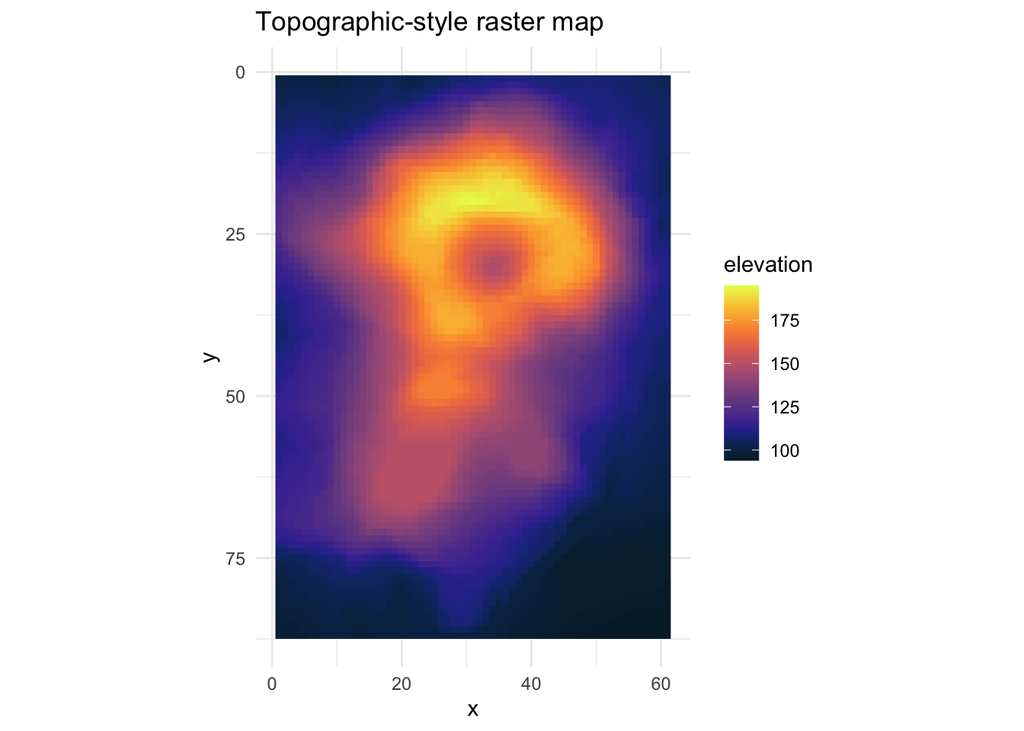

```r
library(terra)
library(tidyterra)
library(cmocean)
library(ggthemes)
library(wesanderson)

volcano_df <- as.data.frame(volcano) |>
  mutate(y = row_number()) |>
  pivot_longer(-y, names_to = "x", values_to = "elevation") |>
  mutate(x = as.numeric(gsub("V", "", x)))

ggplot(volcano_df, aes(x, y, fill = elevation)) +
  geom_raster() + #not the way I choose to do this anymore, but workable for smaller data
  scale_fill_cmocean(name="thermal") +
  coord_equal() +
  scale_y_reverse() +
  theme_minimal() +
  labs(title = "Topographic-style raster map")
```

Here is some code from my Data Science Across Disciplines class this last January looking at instrumented seal data from the Southern Ocean.

First, some data prep. You are not expected to understand this part.

```r
seal_data <- read_csv("~/Dropbox/!middlebury/Teaching/DSAD 1230/DSAD_2026/R_code/MEOP_data_analysis/data/regional_data/par_seal_data.csv")
seal_data_surface <- seal_data |>
  filter(level==1)

raster_dir <- "/Users/caseysmith/Dropbox/!Middlebury/Teaching/DSAD 1230/DSAD_2025/R_code/Argo_vis_shiny_app"

PacSec_bathy <- rast(paste0(raster_dir, "/data/raster/PacSec_bathy.tif"))


#adjust seal data
seal_data_surface <- seal_data_surface |>
  mutate(lon_anti=case_when(lon<0 ~ lon+360,
                            lon>=0 ~lon))

seal_data_mod <- seal_data |>
  mutate(lon_anti=case_when(lon<0 ~ lon+360,
                            lon>=0 ~lon))

world <- map_data("world")
```

First a map with “raster” data.

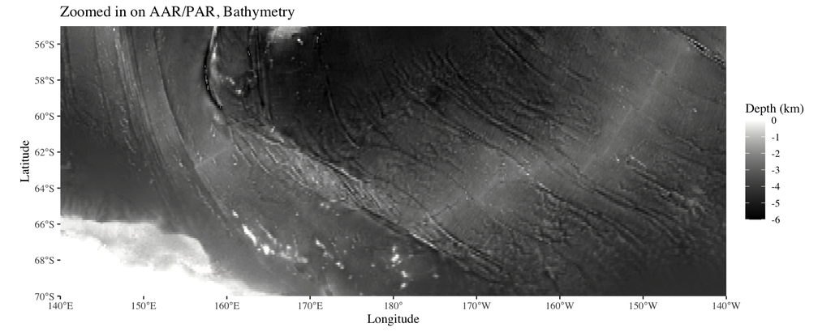

```r
raster_dir <- "/Users/caseysmith/Dropbox/!Middlebury/Teaching/DSAD 1230/DSAD_2025/R_code/Argo_vis_shiny_app"

PacSec_bathy <- rast(paste0(raster_dir, "/data/raster/PacSec_bathy.tif"))

ggplot() +
  geom_spatraster(data=PacSec_bathy) +
  scale_fill_cmocean(name="gray",
                     limits=c(-6000,0),
                     breaks=c(-6000,-5000,-4000,-3000,-2000,-1000,0),
                     labels=c("-6","-5","-4", "-3","-2","-1", "0")) +
  geom_polygon(data = world,
               aes(x = long, y = lat, group = group),
               fill="white", color="white") +
   labs(fill="Depth (km)",
       x="Longitude", y="Latitude") +
  coord_sf(expand=FALSE, xlim = c(140,220), ylim=c(-70,-55) ) +
  ggtitle("Zoomed in on AAR/PAR, Bathymetry") +
  theme_tufte()
```

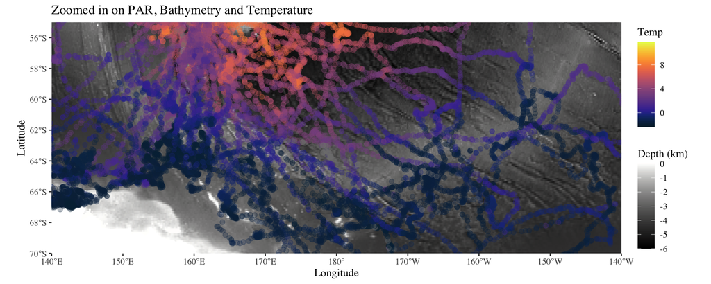

```r
ggplot() +
  geom_spatraster(data=PacSec_bathy) +
  scale_fill_cmocean(name="gray",
                     limits=c(-6000,0),
                     breaks=c(-6000,-5000,-4000,-3000,-2000,-1000,0),
                     labels=c("-6","-5","-4", "-3","-2","-1", "0")) +
  geom_polygon(data = world,
               aes(x = long, y = lat, group = group),
               fill="white", color="white") +
  geom_point(data=seal_data_surface,
             aes(x=lon_anti, y=lat, color=TEMP_ADJUSTED),
             alpha=0.3, size=2) +
  scale_color_cmocean(name="thermal") +
  labs(fill="Depth (km)", color="Temp",
       x="Longitude", y="Latitude") +
  coord_sf(expand=FALSE, xlim = c(140,220), ylim=c(-70,-55) ) +
  ggtitle("Zoomed in on PAR, Bathymetry and Temperature") +
  theme_tufte()
```

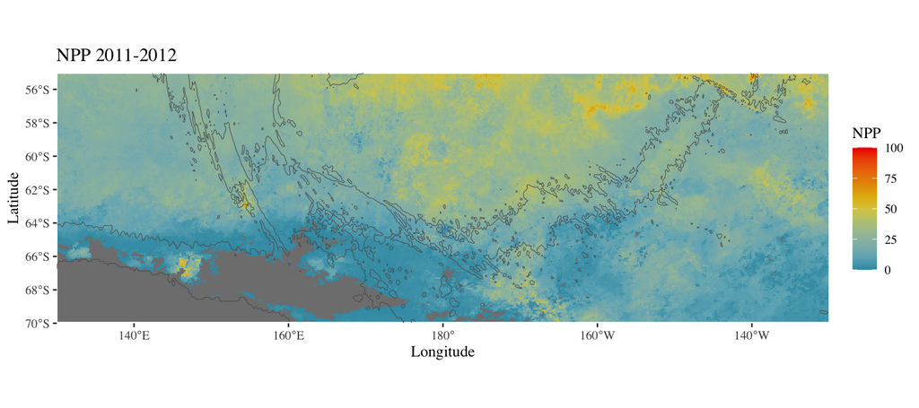

```r
NPP_stack <- rast("~/Dropbox/!Research/Projects/PacAntRidge/data/NPP_raster_stack.nc")

invisible(capture.output({ #to suppress the #$^*@$ progress bar
NPP_stack[NPP_stack >100] = 100 #set max value
NPP_stack[NPP_stack <0] = NA #transform placeholder NA value (-99) to actual NA
}))

#my favorite palette from the wesanderson package
pal <- wes_palette("Zissou1", 100, type = "continuous")
ggplot() +
  geom_spatraster(data=NPP_stack[[15]]) + #index to show layer 15 only
  scale_fill_gradientn(colors=pal, limits=c(0,100)) +
  geom_spatraster_contour(data=PacSec_bathy, breaks=c(0,-3000)) + #contour to show margins of mid ocean ridge
  labs(fill="NPP",
       x = "Longitude",
       y = "Latitude") +
  xlim(130, 230) +
  ylim(-70, -55) +
  coord_sf(expand=FALSE) +
  theme_tufte() +
  ggtitle("NPP 2011-2012")
```

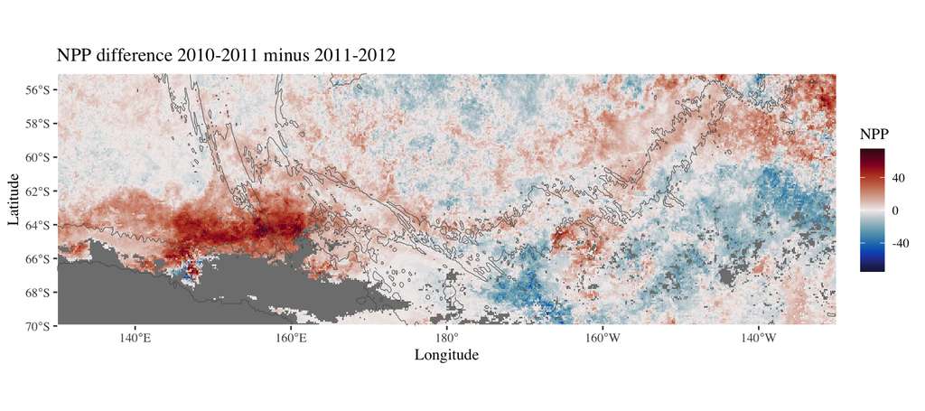

```r
#calculate the difference between the two years, by subtracting one from the other
diff_layer <- NPP_stack[[14]]-NPP_stack[[15]]

diff_layer[diff_layer > 75] = 75 #set max value
diff_layer[diff_layer < (-75)] = -75 #set min value


ggplot() +
  geom_spatraster(data=diff_layer) +
  scale_fill_cmocean(name="balance", limits=c(-75,75)) + #change to diverging palette
  geom_spatraster_contour(data=PacSec_bathy, breaks=c(0,-3000)) +
  labs(fill="NPP",
       x = "Longitude",
       y = "Latitude") +
  xlim(130, 230) +
  ylim(-70, -55) +
  coord_sf(expand=FALSE) + #set this argument so that it doesn't add a border between the map and the axes
  theme_tufte() +
  ggtitle("NPP difference 2010-2011 minus 2011-2012")
```

## Schiny

This is just some example code. We’re not going to run this. I’m going to show you an example from students I had during J-term.

```r
library(shiny)
library(ggplot2)
library(dplyr)
library(palmerpenguins)

ui <- fluidPage(
  selectInput("species", "Species:",
              choices = c("All", unique(na.omit(penguins$species)))),
  plotOutput("plot")
)

server <- function(input, output) {

  filtered <- reactive({
    if (input$species == "All") penguins
    else filter(penguins, species == input$species)
  })

  output$plot <- renderPlot({
    ggplot(filtered(),
           aes(bill_length_mm, flipper_length_mm, color = species)) +
      geom_point() +
      theme_minimal()
  })
}

shinyApp(ui, server)
```

## Github Website

This is a fun one that I would love for you to choose because I really want to learn it. This would also be a very cool thing to be able to put on a resume and showcase all of your cool plots that you’ve made!

Changing my sampler to demonstrate git.